# BMW vs Volkswagen

Beatriz Quevedo

2020-11-30

# Introducción

# Carga de las ibrerías

```r
library(quantmod) #Package to download financials historical data
library(forecast)
library(fGarch)
library(vars)
```

# Creación de las funciones

Prueba del multiplicador de Lagrange para el efecto ARCH de una serie de tiempo.

- **rnt**: series temporales
- **m**: orden del AR seleccionado
- TSAY(2013)

```r
archTest <- function(rtn,m=10){

  y=(rtn-mean(rtn))^2
  T=length(rtn)
  atsq=y[(m+1):T]
  x=matrix(0,(T-m),m)
  for (i in 1:m){
    x[,i]=y[(m+1-i):(T-i)]
  }
  md=lm(atsq~x)
  summary(md)
}
```

Esta funcion será utilizada mas adelante para ver si es necesario realizar la estimación de un modelo GARCH, respondiendo a la primera pregunta.

# BMW

Obtenención de los datos:

```r
BMWSymbol = "BMW.DE"
BMWData <- getSymbols(BMWSymbol ,from = "2014-01-01",to = "2020-01-01", auto.assign = FALSE)
```

```r
xData = Ad(BMWData)
dRentCont = dailyReturn(xData,type = 'log',leading = FALSE)
dRentCont = na.exclude(dRentCont)
```

## Volatilidad GARCH

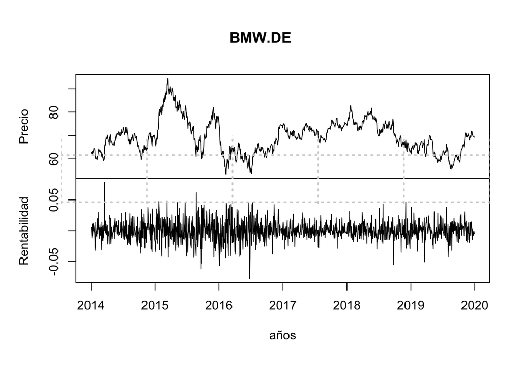

## Volatilidad de GARP

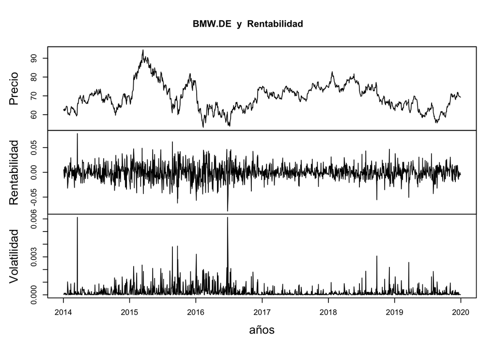

## Testeo de la media

```
##
##  One Sample t-test
##
## data:  dRentCont
## t = 0.17599, df = 1517, p-value = 0.8603
## alternative hypothesis: true mean is not equal to 0
## 95 percent confidence interval:
##  -0.0006889777  0.0008247909
## sample estimates:
##    mean of x
## 6.790663e-05
```

# ACF & PACF

**ACF** es una función de *autocorrelación* (*completa*) que nos da valores de autocorrelación de cualquier serie con sus valores retardados. El **PACF** es una función de *autocorrelación parcial*. Básicamente, en lugar de encontrar correlaciones de presente con desfases como el ACF, encuentra una correlación de los residuos (que permanece después de eliminar los efectos que ya se explican por los desfases anteriores) con el siguiente valor de desfase, por lo tanto, “parcial” y no “completa”, ya que eliminamos las variaciones ya encontradas antes de encontrar la siguiente correlación.

```r
VolProxy=dRentCont^2
```

Para determinar si existen efectos GARCH en la serie de residuos del modelo, se realizarán los contrastes de hipótesis: **Ljung-Box** y el **Multiplicador de Lagrange** para efectos GARCH.

El resultado de estas pruebas, indicará por tanto si es necesario realizar la estimación de un modelo GARCH, respondiendo a la primera pregunta.

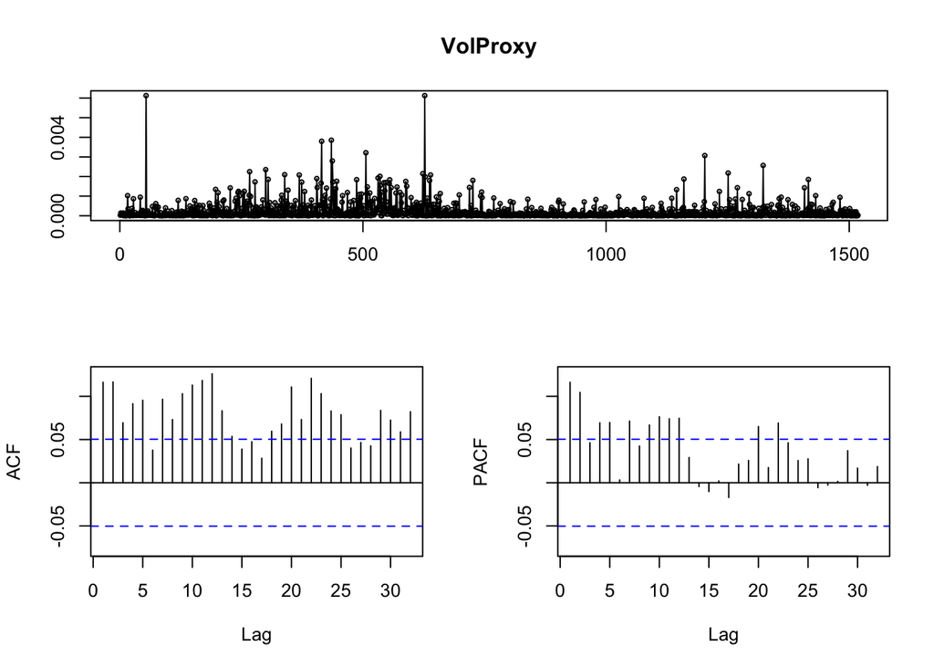

```
##
##  Box-Ljung test
##
## data:  VolProxy
## X-squared = 135.56, df = 10, p-value < 2.2e-16
```

```
##
##  Box-Ljung test
##
## data:  VolProxy
## X-squared = 234.88, df = 20, p-value < 2.2e-16
```

```
##
##  Box-Ljung test
##
## data:  VolProxy
## X-squared = 397.71, df = 40, p-value < 2.2e-16
```

```
##
## Call:
## lm(formula = atsq ~ x)
##
## Residuals:
##        Min         1Q     Median         3Q        Max
## -0.0007212 -0.0001736 -0.0001128  0.0000149  0.0059128
##
## Coefficients:
##               Estimate Std. Error t value Pr(>|t|)
## (Intercept)  8.582e-05  1.939e-05   4.426 1.03e-05 ***
## x1           6.376e-02  2.596e-02   2.456  0.01417 *
## x2           6.562e-02  2.601e-02   2.523  0.01174 *
## x3           1.595e-02  2.606e-02   0.612  0.54067
## x4           4.825e-02  2.606e-02   1.851  0.06433 .
## x5           5.151e-02  2.606e-02   1.977  0.04825 *
## x6          -1.727e-02  2.609e-02  -0.662  0.50811
## x7           4.821e-02  2.609e-02   1.848  0.06487 .
## x8           1.732e-02  2.611e-02   0.663  0.50728
## x9           4.520e-02  2.605e-02   1.735  0.08289 .
## x10          6.010e-02  2.603e-02   2.309  0.02107 *
## x11          6.198e-02  2.603e-02   2.382  0.01737 *
## x12          7.166e-02  2.605e-02   2.751  0.00602 **
## x13          2.719e-02  2.611e-02   1.041  0.29792
## x14         -4.645e-03  2.609e-02  -0.178  0.85872
## x15         -1.335e-02  2.609e-02  -0.512  0.60904
## x16         -1.505e-03  2.606e-02  -0.058  0.95396
## x17         -2.106e-02  2.603e-02  -0.809  0.41867
## x18          1.528e-02  2.603e-02   0.587  0.55724
## x19          2.132e-02  2.598e-02   0.821  0.41206
## x20          6.519e-02  2.593e-02   2.514  0.01204 *
## ---
## Signif. codes:  0 '***' 0.001 '**' 0.01 '*' 0.05 '.' 0.1 ' ' 1
##
## Residual standard error: 0.0004452 on 1477 degrees of freedom
## Multiple R-squared:  0.06908,    Adjusted R-squared:  0.05647
## F-statistic:  5.48 on 20 and 1477 DF,  p-value: 9e-14
```

## ARCH(1)

El modelo *ARCH* es la primera especificación y desarrollo del modelo.

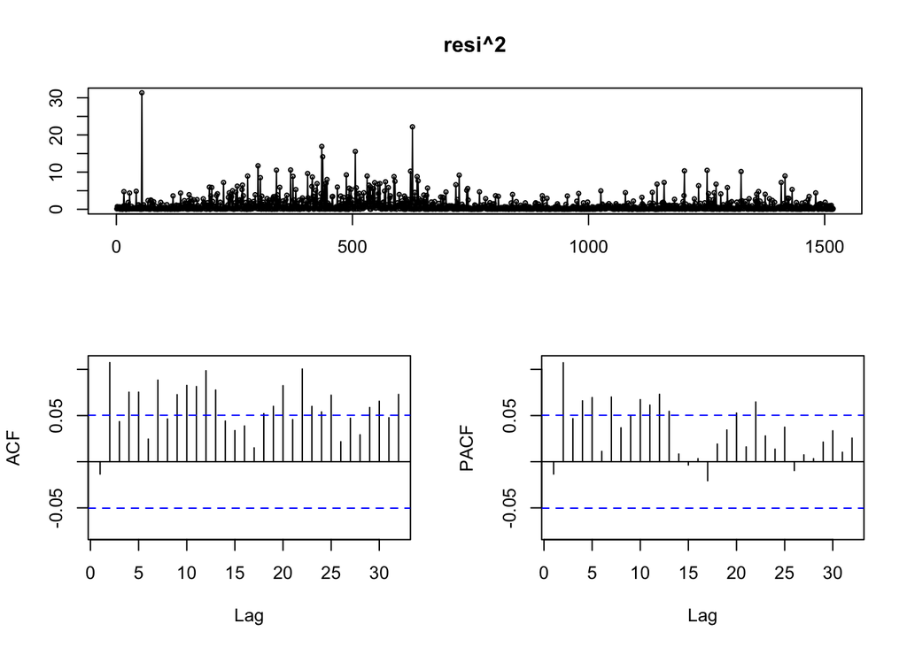

## GARCH (1,1)

Es un método generalizado y sin restricciones para la estimación de los parametros ARCH con **infinitos retardos**.

```
##
## Title:
##  GARCH Modelling
##
## Call:
##  garchFit(formula = ~1 + garch(1, 1), data = dRentCont, trace = F)
##
## Mean and Variance Equation:
##  data ~ 1 + garch(1, 1)
## <environment: 0x7ff04db95a68>
##  [data = dRentCont]
##
## Conditional Distribution:
##  norm
##
## Coefficient(s):
##         mu       omega      alpha1       beta1
## 2.3609e-04  6.5052e-07  2.1211e-02  9.7560e-01
##
## Std. Errors:
##  based on Hessian
##
## Error Analysis:
##         Estimate  Std. Error  t value Pr(>|t|)
## mu     2.361e-04   3.409e-04    0.693   0.4886
## omega  6.505e-07   3.355e-07    1.939   0.0525 .
## alpha1 2.121e-02   3.642e-03    5.823 5.77e-09 ***
## beta1  9.756e-01   3.903e-03  249.957  < 2e-16 ***
## ---
## Signif. codes:  0 '***' 0.001 '**' 0.01 '*' 0.05 '.' 0.1 ' ' 1
##
## Log Likelihood:
##  4307.9    normalized:  2.837879
##
## Description:
##  Mon Nov 30 23:35:45 2020 by user:
##
##
## Standardised Residuals Tests:
##                                 Statistic p-Value
##  Jarque-Bera Test   R    Chi^2  242.9076  0
##  Shapiro-Wilk Test  R    W      0.9841121 6.901744e-12
##  Ljung-Box Test     R    Q(10)  26.63639  0.002972279
##  Ljung-Box Test     R    Q(15)  31.85092  0.006745725
##  Ljung-Box Test     R    Q(20)  38.52619  0.007631821
##  Ljung-Box Test     R^2  Q(10)  3.765989  0.9572868
##  Ljung-Box Test     R^2  Q(15)  4.943707  0.9925924
##  Ljung-Box Test     R^2  Q(20)  8.35668   0.9892325
##  LM Arch Test       R    TR^2   4.321407  0.9769137
##
## Information Criterion Statistics:
##       AIC       BIC       SIC      HQIC
## -5.670488 -5.656456 -5.670502 -5.665264
```

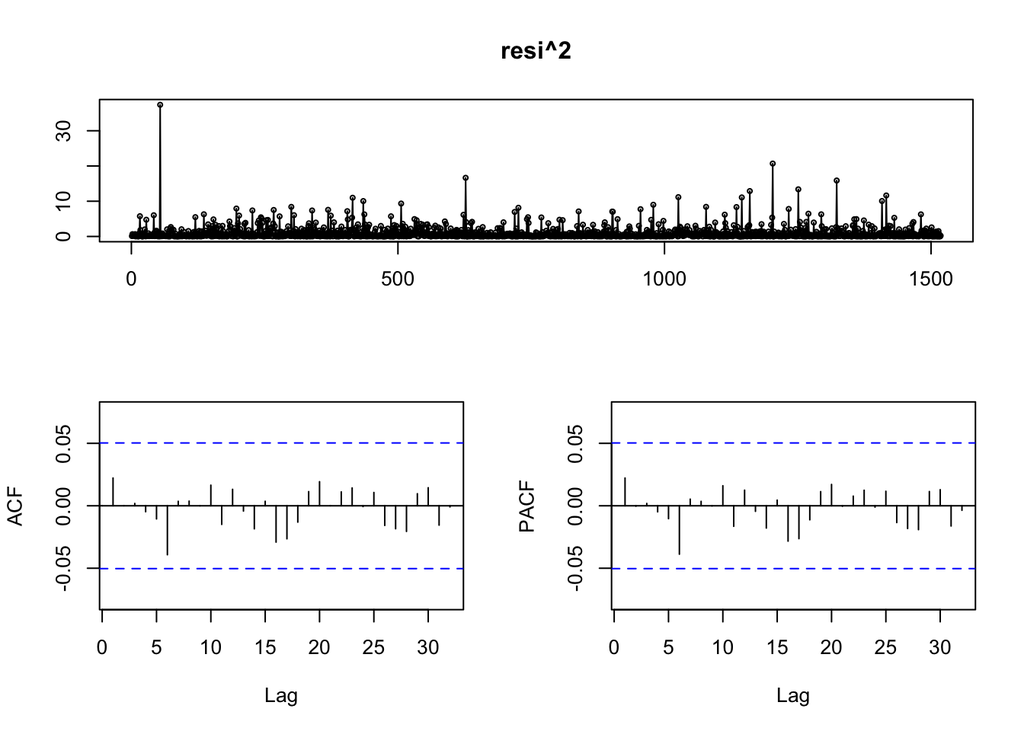

## Volatilidad

La volatilidad es una medida de cuánto la rentabilidad fluctúa alrededor de su media. Es por tanto una medida del riesgo.

Así, es importante poder calcular esta volatilidad en cualquier instante para analizar cómo varía con el tiempo y para predecir sus valores futuros.

Se estandarizan los residuos y se grafican:

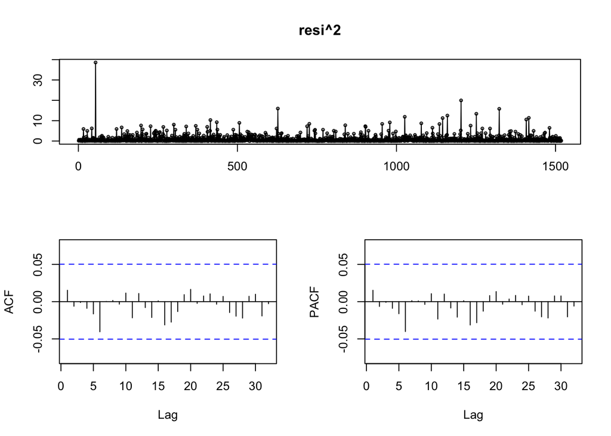

Por ultimo se realiza la predicción de la volatilidad del modelo.

| meanForecast | meanError | standardDeviation |
| --- | --- | --- |
| -8.424914e-06 | 0.01125847 | 0.01125847 |
| -8.424914e-06 | 0.01127329 | 0.01127329 |
| -8.424914e-06 | 0.01128806 | 0.01128806 |
| -8.424914e-06 | 0.01130279 | 0.01130279 |
| -8.424914e-06 | 0.01131748 | 0.01131748 |
| -8.424914e-06 | 0.01133213 | 0.01133213 |
| -8.424914e-06 | 0.01134673 | 0.01134673 |
| -8.424914e-06 | 0.01136129 | 0.01136129 |
| -8.424914e-06 | 0.01137582 | 0.01137582 |
| -8.424914e-06 | 0.01139030 | 0.01139030 |

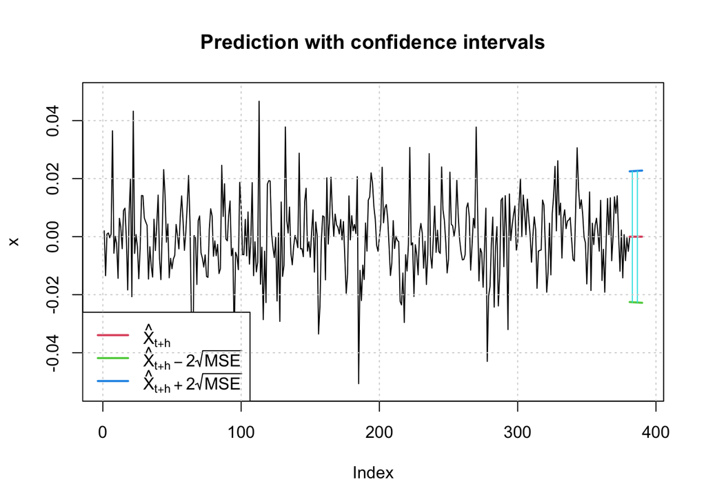

| meanForecast | meanError | standardDeviation | lowerInterval | upperInterval |
| --- | --- | --- | --- | --- |
| -8.424914e-06 | 0.01125847 | 0.01125847 | -0.02252536 | 0.02250851 |
| -8.424914e-06 | 0.01127329 | 0.01127329 | -0.02255500 | 0.02253815 |
| -8.424914e-06 | 0.01128806 | 0.01128806 | -0.02258455 | 0.02256770 |
| -8.424914e-06 | 0.01130279 | 0.01130279 | -0.02261401 | 0.02259716 |
| -8.424914e-06 | 0.01131748 | 0.01131748 | -0.02264339 | 0.02262654 |
| -8.424914e-06 | 0.01133213 | 0.01133213 | -0.02267268 | 0.02265583 |
| -8.424914e-06 | 0.01134673 | 0.01134673 | -0.02270189 | 0.02268504 |
| -8.424914e-06 | 0.01136129 | 0.01136129 | -0.02273101 | 0.02271416 |
| -8.424914e-06 | 0.01137582 | 0.01137582 | -0.02276006 | 0.02274321 |
| -8.424914e-06 | 0.01139030 | 0.01139030 | -0.02278902 | 0.02277217 |

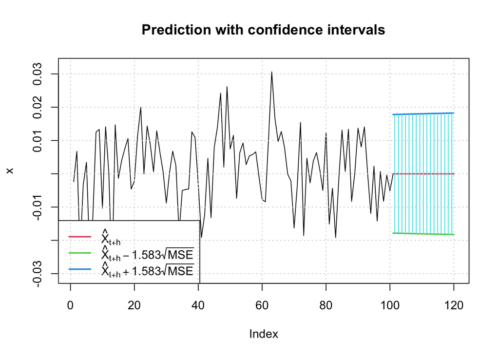

| meanForecast | meanError | standardDeviation | lowerInterval | upperInterval |
| --- | --- | --- | --- | --- |
| -8.424914e-06 | 0.01125847 | 0.01125847 | -0.01783007 | 0.01781322 |
| -8.424914e-06 | 0.01127329 | 0.01127329 | -0.01785353 | 0.01783668 |
| -8.424914e-06 | 0.01128806 | 0.01128806 | -0.01787691 | 0.01786006 |
| -8.424914e-06 | 0.01130279 | 0.01130279 | -0.01790023 | 0.01788338 |
| -8.424914e-06 | 0.01131748 | 0.01131748 | -0.01792348 | 0.01790663 |
| -8.424914e-06 | 0.01133213 | 0.01133213 | -0.01794667 | 0.01792982 |
| -8.424914e-06 | 0.01134673 | 0.01134673 | -0.01796979 | 0.01795294 |
| -8.424914e-06 | 0.01136129 | 0.01136129 | -0.01799284 | 0.01797599 |
| -8.424914e-06 | 0.01137582 | 0.01137582 | -0.01801582 | 0.01799897 |
| -8.424914e-06 | 0.01139030 | 0.01139030 | -0.01803875 | 0.01802190 |

[output cut: 10 more lines]

# Modelo VAR (Vectores Autorregresivos)

En un VAR, todas las variables son tratadas *simétricamente.* Todos ellos son modelizados como si se influyeran entre sí por igual. En una terminología más formal, todas las variables son ahora tratadas como “*endógenas*”

## Rentabilidad mensual del modelo

```r
rbmw=monthlyReturn(bmw[,6])
rvol=monthlyReturn(vol[,6])
```

## Generación del vector

```r
vY=cbind(rbmw,rvol)
colnames(vY)=c("BMW","VOL")
vY=na.omit(vY)
```

## Selección del modelo

```
## $selection
## AIC(n)  HQ(n)  SC(n) FPE(n)
##      2      2      2      2
##
## $criteria
##                    1    2    3    4    5    6    7    8    9   10
## AIC(n) -4.391959e+01 -Inf -Inf -Inf -Inf -Inf -Inf -Inf -Inf -Inf
## HQ(n)  -4.593969e+01 -Inf -Inf -Inf -Inf -Inf -Inf -Inf -Inf -Inf
## SC(n)  -4.484015e+01 -Inf -Inf -Inf -Inf -Inf -Inf -Inf -Inf -Inf
## FPE(n)  2.057200e-19    0    0    0    0    0    0    0    0    0
```

# Estimación

```
##
## VAR Estimation Results:
## =========================
## Endogenous variables: BMW, VOL
## Deterministic variables: const
## Sample size: 13
## Log Likelihood: 34.903
## Roots of the characteristic polynomial:
## 0.434 0.1406
## Call:
## VAR(y = vY)
##
##
## Estimation results for equation BMW:
## ====================================
## BMW = BMW.l1 + VOL.l1 + const
##
##        Estimate Std. Error t value Pr(>|t|)
## BMW.l1 -0.07643    0.94710  -0.081    0.937
## VOL.l1 -0.06376    0.91166  -0.070    0.946
## const   0.02113    0.03602   0.586    0.571
##
##
## Residual standard error: 0.1292 on 10 degrees of freedom
## Multiple R-Squared: 0.01357, Adjusted R-squared: -0.1837
## F-statistic: 0.06879 on 2 and 10 DF,  p-value: 0.934
##
##
## Estimation results for equation VOL:
## ====================================
## VOL = BMW.l1 + VOL.l1 + const
##
##        Estimate Std. Error t value Pr(>|t|)
## BMW.l1  0.35965    0.94896   0.379    0.713
## VOL.l1 -0.49814    0.91345  -0.545    0.597
## const   0.01587    0.03609   0.440    0.669
##
##
## Residual standard error: 0.1294 on 10 degrees of freedom
## Multiple R-Squared: 0.03759, Adjusted R-squared: -0.1549
## F-statistic: 0.1953 on 2 and 10 DF,  p-value: 0.8257
##
##
##
## Covariance matrix of residuals:
##         BMW     VOL
## BMW 0.01668 0.01589
## VOL 0.01589 0.01675
##
## Correlation matrix of residuals:
##        BMW    VOL
## BMW 1.0000 0.9505
## VOL 0.9505 1.0000
```

```
##
## VAR Estimation Results:
## =========================
## Endogenous variables: BMW, VOL
## Deterministic variables: none
## Sample size: 13
## Log Likelihood: 34.594
## Roots of the characteristic polynomial:
## 0.4242 0.127
## Call:
## VAR(y = vY, type = "none")
##
##
## Estimation results for equation BMW:
## ====================================
## BMW = BMW.l1 + VOL.l1
##
##        Estimate Std. Error t value Pr(>|t|)
## BMW.l1 -0.02059    0.91377  -0.023    0.982
## VOL.l1 -0.10695    0.88117  -0.121    0.906
##
##
## Residual standard error: 0.1252 on 11 degrees of freedom
## Multiple R-Squared: 0.01144, Adjusted R-squared: -0.1683
## F-statistic: 0.06368 on 2 and 11 DF,  p-value: 0.9387
##
##
## Estimation results for equation VOL:
## ====================================
## VOL = BMW.l1 + VOL.l1
##
##        Estimate Std. Error t value Pr(>|t|)
## BMW.l1   0.4016     0.9089   0.442    0.667
## VOL.l1  -0.5306     0.8764  -0.605    0.557
##
##
## Residual standard error: 0.1246 on 11 degrees of freedom
## Multiple R-Squared: 0.03907, Adjusted R-squared: -0.1356
## F-statistic: 0.2236 on 2 and 11 DF,  p-value: 0.8032
##
##
##
## Covariance matrix of residuals:
##         BMW     VOL
## BMW 0.01517 0.01445
## VOL 0.01445 0.01523
##
## Correlation matrix of residuals:
##        BMW    VOL
## BMW 1.0000 0.9505
## VOL 0.9505 1.0000
```

## Causalidad de granger

Con este test se comprueba si una variable es útil para pronosticar otra.

```
## $Granger
##
##  Granger causality H0: BMW do not Granger-cause VOL
##
## data:  VAR object model.var1
## F-Test = 0.19524, df1 = 1, df2 = 22, p-value = 0.6629
##
##
## $Instant
##
##  H0: No instantaneous causality between: BMW and VOL
##
## data:  VAR object model.var1
## Chi-squared = 6.1722, df = 1, p-value = 0.01298
```

## Respuesta al impulso

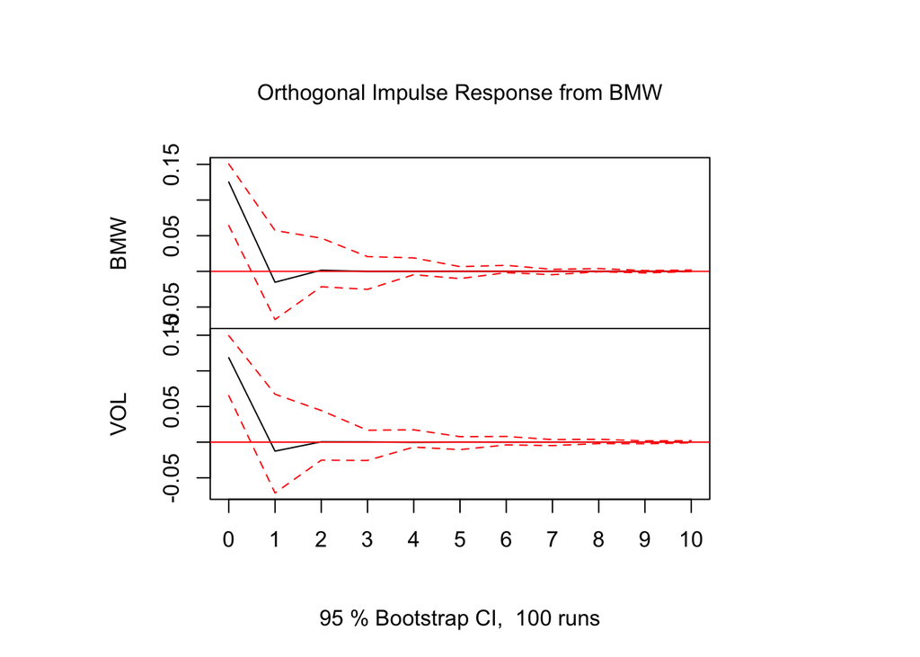

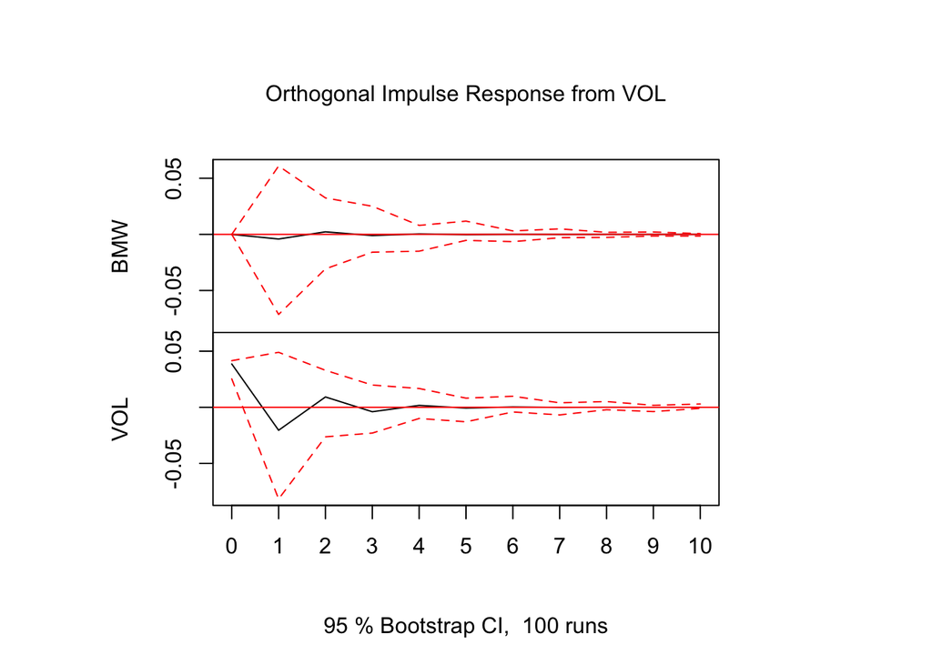

# Predicción

```
## $BMW
##               fcst      lower     upper        CI
## [1,] -2.971663e-02 -0.2751995 0.2157662 0.2454829
## [2,]  3.148651e-03 -0.2442788 0.2505761 0.2474275
## [3,] -1.344242e-04 -0.2476234 0.2473545 0.2474889
## [4,] -9.554954e-05 -0.2475928 0.2474017 0.2474973
## [5,]  5.990795e-05 -0.2474389 0.2475587 0.2474988
## [6,] -2.787237e-05 -0.2475270 0.2474712 0.2474991
## [7,]  1.213513e-05 -0.2474870 0.2475113 0.2474992
## [8,] -5.186999e-06 -0.2475044 0.2474940 0.2474992
##
## $VOL
##               fcst      lower     upper        CI
## [1,] -2.371857e-02 -0.2678868 0.2204497 0.2441683
## [2,]  6.506443e-04 -0.2480147 0.2493160 0.2486654
## [3,]  9.192776e-04 -0.2484026 0.2502412 0.2493219
## [4,] -5.417473e-04 -0.2499863 0.2489028 0.2494446
## [5,]  2.490744e-04 -0.2492180 0.2497162 0.2494671
## [6,] -1.080979e-04 -0.2495793 0.2493631 0.2494712
## [7,]  4.616239e-05 -0.2494257 0.2495181 0.2494719
## [8,] -1.961995e-05 -0.2494917 0.2494524 0.2494720
```